# Australian RSCPA Animal Outcomes

Ben Norland

7/24/2020

This week’s Tidy Tuesday dataset contains outcomes for animals taken into care by Australia’s RSPCA.

I’m going to specifically explore how outcomes for dogs and cats have changed over time.

Firstly, we’ll load in the data and see what we’re working with.

```r
# Load libraries
library(tidytuesdayR)
library(tidyverse)
library(ggthemes)

# Create colour palette
Background_Main="#1E2639"
Background_Light="#27455B"
Outlines="#0C0F17"
Text_1="#E9E9EB"
Text_2="#D2D4D7"
Contrast_1="#B9BEBA"
Highlight_1="#C72523"
Highlight_1_Accent="#951E22"
Highlight_2="#4D8AB5"
Highlight_3="#EFA53A"
Highlight_4="#35B535"
Highlight_5="#2C2A89"

# Load data
tuesdata=tt_load(2020,week = 30)
animal_outcomes=tuesdata$animal_outcomes
head(animal_outcomes)
```

```
## # A tibble: 6 x 12
##    year animal_type outcome   ACT   NSW    NT   QLD    SA   TAS   VIC    WA
##   <dbl> <chr>       <chr>   <dbl> <dbl> <dbl> <dbl> <dbl> <dbl> <dbl> <dbl>
## 1  1999 Dogs        Reclai…   610  3140   205  1392  2329   516  7130     1
## 2  1999 Dogs        Rehomed  1245  7525   526  5489  1105   480  4908   137
## 3  1999 Dogs        Other      12   745   955   860   380   168  1001     6
## 4  1999 Dogs        Euthan…   360  9221     9  9214  1701   599  5217    18
## 5  1999 Cats        Reclai…   111   201    22   206   157    31   884     0
## 6  1999 Cats        Rehomed  1442  3913   269  3901  1055   752  3768    62
## # … with 1 more variable: Total <dbl>
```

The first thing we’ll do is transform this into a long-form dataset, creating a “State” column and a “Count” column, rather than keeping this “wide” dataset:

```r
# Pivot data to long form
animal_outcomes_long=animal_outcomes%>%
  pivot_longer(-c(year,animal_type,outcome),names_to = "State",values_to="Count")

head(animal_outcomes_long)
```

```
## # A tibble: 6 x 5
##    year animal_type outcome   State Count
##   <dbl> <chr>       <chr>     <chr> <dbl>
## 1  1999 Dogs        Reclaimed ACT     610
## 2  1999 Dogs        Reclaimed NSW    3140
## 3  1999 Dogs        Reclaimed NT      205
## 4  1999 Dogs        Reclaimed QLD    1392
## 5  1999 Dogs        Reclaimed SA     2329
## 6  1999 Dogs        Reclaimed TAS     516
```

Great - having the data in this format makes it much easier for onward processing.

Next, let’s review the different outcomes that we’re dealing with.

```r
# Find outcome types
unique(animal_outcomes_long$outcome)
```

```
## [1] "Reclaimed"         "Rehomed"           "Other"
## [4] "Euthanized"        "Released"          "In Stock"
## [7] "Transferred"       "Currently In Care"
```

It looks like a couple of the outcomes - “In Stock” and “Currently In Care” - are non-definitive. In other words, we still don’t know what will happen to these animals in the longer term. So when considering outcomes, we’ll remove these cases from our analysis.

What I’d love to understand is how the outcomes break down in terms of positive outcomes - i.e. cases that didn’t result in the animal being Euthanized.

Let’s pull together a summary table, showing how each state performed for each animal group in each year, in terms of positive outcome %, along with a few other key stats.

```r
# Group by state, animal, and year
state_totals=animal_outcomes_long%>%
  group_by(State,year,animal_type)%>%
  summarise(Total=sum(Count),
            Outcome_Achieved=sum(Count[!outcome %in% c("In Stock","Currently In Care")]),
            Euthanized=sum(Count[outcome=="Euthanized"]),
            Reclaimed=sum(Count[outcome=="Reclaimed"]),
            Rehomed=sum(Count[outcome=="Rehomed"]),
            Outcome_Not_Reclaimed=sum(Count[!outcome %in% c("In Stock","Currently In Care","Reclaimed")]))%>%
  mutate(Positive_Outcome=1-round(Euthanized/Outcome_Achieved,3),
         Reclaim_Prop=round(Reclaimed/Outcome_Achieved,3),
         Rehome_Prop=round(Rehomed/Outcome_Not_Reclaimed,3))%>%
  select(State,year,animal_type,Total,Outcome_Achieved,Positive_Outcome,Reclaim_Prop,Rehome_Prop)

head(state_totals)
```

```
## # A tibble: 6 x 8
## # Groups:   State, year [1]
##   State  year animal_type Total Outcome_Achieved Positive_Outcome Reclaim_Prop
##   <chr> <dbl> <chr>       <dbl>            <dbl>            <dbl>        <dbl>
## 1 ACT    1999 Cats         2560             2560            0.607        0.043
## 2 ACT    1999 Dogs         2227             2227            0.838        0.274
## 3 ACT    1999 Horses          1                1            1            0
## 4 ACT    1999 Livestock     140              140            0.936        0.014
## 5 ACT    1999 Other Anim…   393              393            0.781        0.079
## 6 ACT    1999 Wildlife     1309             1309            0.43         0
## # … with 1 more variable: Rehome_Prop <dbl>
```

Now the data is in a format for our visualisation. We can see the proportion of positive outcomes per animal/state/year combination.

Let’s visualise the total positive outcome rates over time for cats and dogs.

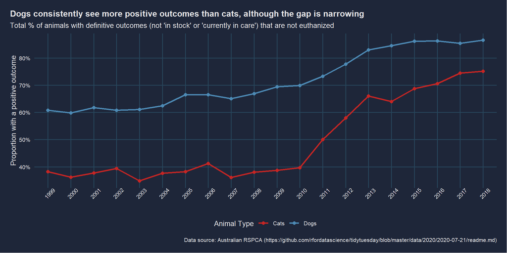

```r
# Filter to focus on dogs and cats only
dogs_cats=state_totals%>%
  filter(animal_type %in% c("Dogs","Cats"))

# Visualise total positive outcome rate for dogs and cats by year
dogs_cats%>%
  filter(State=="Total")%>%
  ggplot(aes(x=factor(year),y=Positive_Outcome,col=animal_type))+
  geom_line(aes(group=animal_type),size=1)+
  geom_point(size=2)+
  theme_fivethirtyeight()+
  theme(axis.title = element_text(size=10,colour=Text_1),
        axis.text.y = element_text(size=8,colour=Text_1),
        panel.grid.major.x = element_line(colour = Background_Light),
        panel.grid.major.y = element_line(colour = Background_Light),
        axis.text.x=element_text(size=8,colour = Text_1,angle=45),
        plot.title = element_text(size=12,colour = Text_1),
        plot.subtitle=element_text(size=10,colour = Text_1),
        plot.caption=element_text(size=8,colour = Text_1),
        plot.background = element_rect(fill=Background_Main),
        panel.background = element_rect(fill=Background_Main),
        panel.border = element_rect(colour=Background_Main,size=0,linetype = "solid"),
        legend.key = element_rect(fill=Background_Main),
        legend.background = element_rect(fill=Background_Main),
        legend.text = element_text(colour=Text_1,size=8),
        legend.title = element_text(colour=Text_1,size=10),
        legend.position = "bottom",
        legend.direction = "horizontal",
        plot.title.position = "plot")+
  labs(title=paste0("Dogs consistently see more positive outcomes than cats, although the gap is narrowing"),
       subtitle=paste0("Total % of animals with definitive outcomes (not 'in stock' or 'currently in care') that are not euthanized"),
       caption="Data source: Australian RSPCA (https://github.com/rfordatascience/tidytuesday/blob/master/data/2020/2020-07-21/readme.md)",
       y="Proportion with a positive outcome",
       x=NULL,
       color="Animal Type")+
  scale_y_continuous(labels = scales::percent_format(accuracy = 1))+
  scale_color_manual(values=c(Highlight_1,Highlight_2))
```

We can see that dogs have consistently seen more positive outcomes than cats over this period. However, the gap has narrowed significantly in the past decade, and both dogs and cats have seen improvements in outcomes.

However, it would be interesting to understand why the gap exists. One potential factor might be to do with reclaim rates, as shown in the chart below:

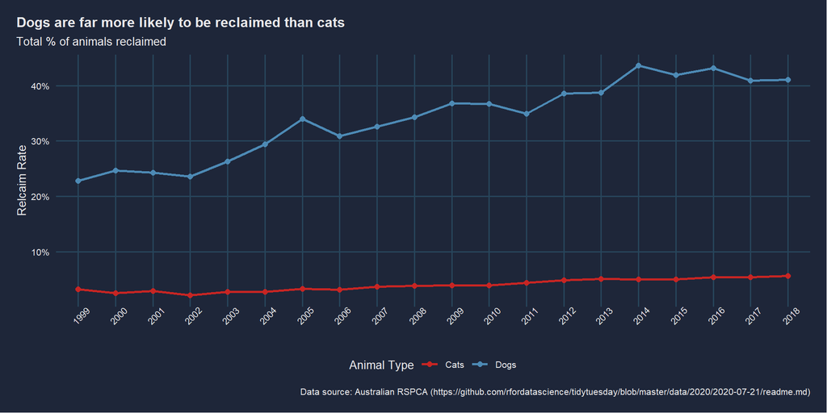

```r
# Visualise total reclaim rate for dogs and cats by year
dogs_cats%>%
  filter(State=="Total")%>%
  ggplot(aes(x=factor(year),y=Reclaim_Prop,col=animal_type))+
  geom_line(aes(group=animal_type),size=1)+
  geom_point(size=2)+
  theme_fivethirtyeight()+
  theme(axis.title = element_text(size=10,colour=Text_1),
        axis.text.y = element_text(size=8,colour=Text_1),
        panel.grid.major.x = element_line(colour = Background_Light),
        panel.grid.major.y = element_line(colour = Background_Light),
        axis.text.x=element_text(size=8,colour = Text_1,angle=45),
        plot.title = element_text(size=12,colour = Text_1),
        plot.subtitle=element_text(size=10,colour = Text_1),
        plot.caption=element_text(size=8,colour = Text_1),
        plot.background = element_rect(fill=Background_Main),
        panel.background = element_rect(fill=Background_Main),
        panel.border = element_rect(colour=Background_Main,size=0,linetype = "solid"),
        legend.key = element_rect(fill=Background_Main),
        legend.background = element_rect(fill=Background_Main),
        legend.text = element_text(colour=Text_1,size=8),
        legend.title = element_text(colour=Text_1,size=10),
        legend.position = "bottom",
        legend.direction = "horizontal",
        plot.title.position = "plot")+
  labs(title=paste0("Dogs are far more likely to be reclaimed than cats"),
       subtitle=paste0("Total % of animals reclaimed"),
       caption="Data source: Australian RSPCA (https://github.com/rfordatascience/tidytuesday/blob/master/data/2020/2020-07-21/readme.md)",
       y="Relcaim Rate",
       x=NULL,
       color="Animal Type")+
  scale_y_continuous(labels = scales::percent_format(accuracy = 1))+
  scale_color_manual(values=c(Highlight_1,Highlight_2))
```

We can see from this that cats are far less likely to be reclaimed than dogs, and that this could be a key reason for their lower positive outcome rate. There could be a number of reasons for this - cats are more likely to stray further from their home than dogs, so it may be harder to track down the owners of those picked up by the RSPCA.

It would also be interesting to see whether any states perform particularly well in terms of positive outcomes. We’ll create a faceted chart below to analyse this:

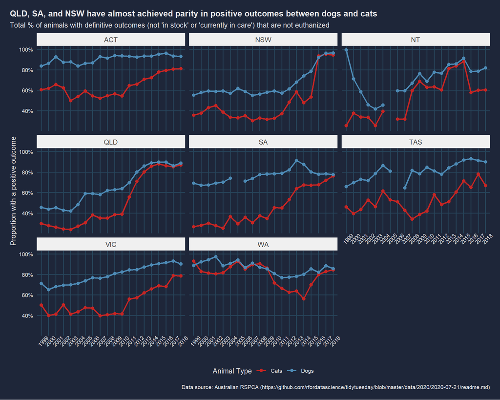

```r
# Visualise positive outcome rate for dogs and cats by year, by state
dogs_cats%>%
  filter(State!="Total")%>%
  ggplot(aes(x=factor(year),y=Positive_Outcome,col=animal_type))+
  geom_line(aes(group=animal_type),size=1)+
  geom_point(size=2)+
  theme_fivethirtyeight()+
  theme(axis.title = element_text(size=10,colour=Text_1),
        axis.text.y = element_text(size=8,colour=Text_1),
        panel.grid.major.x = element_line(colour = Background_Light),
        panel.grid.major.y = element_line(colour = Background_Light),
        axis.text.x=element_text(size=8,colour = Text_1,angle=45),
        plot.title = element_text(size=12,colour = Text_1),
        plot.subtitle=element_text(size=10,colour = Text_1),
        plot.caption=element_text(size=8,colour = Text_1),
        plot.background = element_rect(fill=Background_Main),
        panel.background = element_rect(fill=Background_Main),
        panel.border = element_rect(colour=Background_Main,size=0,linetype = "solid"),
        legend.key = element_rect(fill=Background_Main),
        legend.background = element_rect(fill=Background_Main),
        legend.text = element_text(colour=Text_1,size=8),
        legend.title = element_text(colour=Text_1,size=10),
        legend.position = "bottom",
        legend.direction = "horizontal",
        plot.title.position = "plot")+
  labs(title=paste0("QLD, SA, and NSW have almost achieved parity in positive outcomes between dogs and cats"),
       subtitle=paste0("Total % of animals with definitive outcomes (not 'in stock' or 'currently in care') that are not euthanized"),
       caption="Data source: Australian RSPCA (https://github.com/rfordatascience/tidytuesday/blob/master/data/2020/2020-07-21/readme.md)",
       y="Proportion with a positive outcome",
       x=NULL,
       color="Animal Type")+
  scale_y_continuous(labels = scales::percent_format(accuracy = 1))+
  scale_color_manual(values=c(Highlight_1,Highlight_2))+
  facet_wrap(~State)
```

We can see that a number of states - Queensland, South Australia, and New South Wales - have almost eliminated the gap in outcomes between dogs and cats in recent years, with NSW also achieving extremely high positive outcome rates for both types of animal. Some of the other states might benefit from reviewing the approaches taken in these areas to improving outcomes.